# RSE Skills

## Types of Licenses

- Public Domain, Permissive, Copyleft

[figure not shown]

License guide by [TechTarget](https://www.techtarget.com/searchcio/definition/software-license) under fair use

## How to choose a license

- https://choosealicense.com/licenses/
- Permissive licenses:
  - Apache License 2.0
  - MIT License
- Copyleft:
  - Means that copy/adaption has to use the same license
  - GNU General Public License v3.0

[figure not shown]

[figure not shown]

[figure not shown]

GPL3 image is in the Public Domain  
MIT logo is in the Public Domain  
Apache License image by Apache Software Foundation under Apache License 2.0

## Example: MIT License

```
Copyright <YEAR> <COPYRIGHT HOLDER>

Permission is hereby granted, free of charge, to any person obtaining a copy of this software and associated documentation files (the “Software”), to deal in the Software without restriction, including without limitation the rights to use, copy, modify, merge, publish, distribute, sublicense, and/or…

The above copyright notice and this permission notice shall be included in all copies or substantial portions of the Software.

THE SOFTWARE IS PROVIDED “AS IS”, WITHOUT WARRANTY OF ANY KIND, EXPRESS OR IMPLIED, INCLUDING BUT NOT LIMITED TO THE WARRANTIES OF MERCHANTABILITY, FITNESS FOR A PARTICULAR PURPOSE AND NONINFRINGEMENT. IN NO EVENT SHALL THE AUTHORS OR COPYRIGHT HOLDERS BE LIABLE FOR ANY CLAIM, DAMAGES OR OTHER LIABI…
```

## Add a license in Github

[figure not shown]

## Add a license in Gitlab

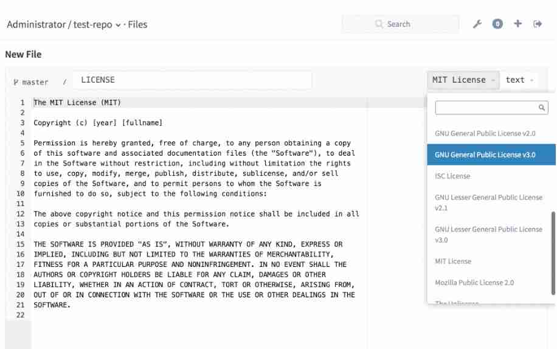

## Other potential files in your repository

- CONTRIBUTING.md
- CITATION.cff
- CODE_OF_CONDUCT.md
- CHANGES.md

# Closing

## Other things

Beyond the scope of today are a few other honourable mentions:

- Functions and modules
- Packaging
  - Breaking projects into modules and `__init__.py`
  - Distributing projects with `pyproject.toml`
- Documentation
  - Auto-generation from docstrings with sphinx or mkdocs
- Type hinting
  - Adding type hinting to python code - how and why?
  - Type checking with mypy

These lessons are beyond the scope of today.

## Discussion

- What have you learnt that you wish you knew earlier?
- Do you have alternatives/disagreements?
- What would you have hoped to learn that wasn’t covered?
- What problems are you having?

## Where can I get help?

If you would like to discuss applying this to your own codebase consider signing up for an ICCS Climate Code Clinic:

- 1hr slot
- RSEs will review code in advance and provide feedback and guidance.
- [Online booking form](https://iccs.cam.ac.uk/resources-vesri-members/climate-code-clinic)

There is also the option of booking in all week during the summer school via the [Booking Sheet](https://docs.google.com/spreadsheets/d/1v8y2GodI9JZoHrFRpLW2tD135MurDBMIcr-ArBFIT3A/edit?usp=sharing).

We will also be available during the mini-project slots on Thursday to help you apply these principles to any code, existing or new.

## Where can I learn more?

- References and links in these slides
- Writing Clean Scientific Software Webinar (Murphy 2023)
- [RSE Society](https://linktr.ee/researchsofteng) (incl. Slack workspace)
- Byte-sized RSE: https://www.universe-hpc.ac.uk/events/byte-sized-rse/
- [The Carpentries](https://carpentries.org/)
- [RSE Toolkit](https://rsetoolkit.github.io/) (wip)

Get in touch:

Jack Atkinson

jackatkinson.net

jwa34[AT]cam.ac.uk

jatkinson1000

[@jatkinson1000@hachyderm.io](https://hachyderm.io/@jatkinson1000)

Marion Weinzierl

mw925[AT]cam.ac.uk

MarionBWeinzierl

[@MarionBWeinzierl@mast.hpc.social](https://mast.hpc.social/@MarionBWeinzierl)

## References

The geoscience code in this workshop is based on a script from Irving (2019). The astrophysics code in this workshop is based on a notebook kindly provided by Anke Ardern-Arentsen ([@ankearentsen](https://github.com/ankearentsen)) of the Institute of Astronomy at the University of Cambridge.

Astral. 2025. *Ruff: An extremely fast Python linter and code formatter, written in Rust.* Version 0.11.3. [Https://github.com/astral-sh/ruff](https://github.com/astral-sh/ruff). (https://docs.astral.sh/ruff/.

Cannon, B, D Ingram, P Ganssle, et al. 2020. *PEP 621 – Storing project metadata in pyproject.toml*. [Https://peps.python.org/pep-0621/](https://peps.python.org/pep-0621/).

Goodger, D, and G van Rossum. 2001. *PEP 257 – Docstring Conventions*. [Https://peps.python.org/pep-0257/](https://peps.python.org/pep-0257/).

Irving, Damien. 2019. “Python for Atmosphere and Ocean Scientists.” *Journal of Open Source Education* 2 (16): 37. https://doi.org/10.21105/jose.00037.

Murphy, N. 2023. “Writing Clean Scientific Software.” https://www.youtube.com/watch?v=Q6Ksu_uX3bc.

Rossum, G van, B Warsaw, and A Coghlan. 2001, 2013. *PEP8 – Style Guide for Python Code*. [Https://peps.python.org/pep-0008/](https://peps.python.org/pep-0008/).

Spertus, E. 2021. *stackoverflow - Best practices for writing code comments*. [Https://stackoverflow.blog/2021/12/23/best-practices-for-writing-code-comments/](https://stackoverflow.blog/2021/12/23/best-practices-for-writing-code-comments/).